# Bewegte Kinder = Gesündere Kinder (BeKiGeKi)

Veröffentlichungsdatum

24. April 2023

Geändert

17. September 2026

Willkommen auf den Ergebnisseiten von “Bewegte Kinder = Gesündere Kinder” (BeKiGeKi), ein thüringenweites Programm zur Unterstützung der bewegungsbezogenen Kompetenzen von Kindern im Grundschulalter. Sie finden hier eine öffentliche Berichterstattung der aufgenommenen Daten und Ergebnisse des Programms. Damit wollen wir unseren Beitrag zur Informations-Transparenz leisten sowie einen gesellschaftlichen Wissenstransfer fördern.

[figure not shown]

Ziele

Das Programm begann in Thüringen mit dem Schuljahr 2017/2018. Die sechs standardisierten Tests oder “Bewegungs-Checks” (6-Minuten-Lauf, 20-Meter-Sprint, Sternlauf, Standweitsprung, Medizinballstoßen und Einbeinstand) sind mit den Tests des Vorreiter-Projektes [EMOTIKON](https://www.uni-potsdam.de/de/emotikon/index) im Land Brandenburg identisch, wodurch neben landesinternen auch bundeslandübergreifende [Vergleichsstudien](https://www.researchgate.net/lab/German-Kids-Fitness-Lab-Reinhold-Kliegl) ermöglicht werden.

Seit dem Schuljahr 2022/2023 ist die Durchführung der Bewegungs-Checks in allen Dritten Klassen ein verpflichtender Bestandteil des Schulsports für alle Grundschulen, wodurch sich der sprunghafte Anstieg in den erfassten Schulen und Kindern nach den Corona-Schutzmaßnahmen in der folgenden erklärt.

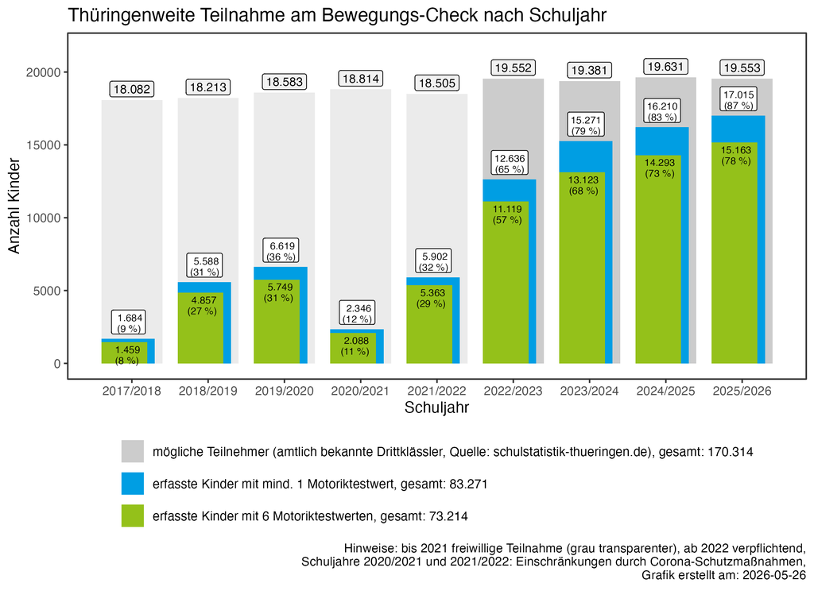

Teilnahmeentwicklung

## TODO

- Erläuterungen zur Einführung Beweungschecks bzgl. Inklusion
- Abbildung zu Phasen im Schuljahresverlauf (Test-Phase, Veranstaltungsphase, Auswertungs- und Evaluationsphase)

## Datengrundlage

- Schuladressen, -nummern und -namen: https://www.schulportal-thueringen.de/schools (Stand 24. April 2023
- Geocoding: Cambon J, Hernangómez D, Belanger C, Possenriede D (2021). tidygeocoder: An R package for geocoding. Journal of Open Source Software, 6(65), 3544, https://doi.org/10.21105/joss.03544 (R package version 1.0.5 with ArcGIS Method)
- Messdaten im Excelformat von den Schulen, die am Programm “BEWEGTE KINDER=GESÜNDERE KINDER” (BeKiGeKi) teilnahmen

## Aktualisierungen

- 2026-05-21: Teilnehmerzahlen 2026 mit geschätzten möglichen Teilnehmern
- 2024-08-26: Erläuterungen, Links zu Vorreiter-Projekt und Studien, Ziele- und Teilnehmerabbildung
- 2024-04-21: Punktgröße: Anzahl Teilnahmen, Schule 76388
- 2024-02-28: Neue Daten Schuljahr 2023/2024
- 2023-08-25: [Link to German Kids Fitness Lab](https://www.researchgate.net/lab/German-Kids-Fitness-Lab-Reinhold-Kliegl)
- 2023-05-10: Abschnitt Datengrundlage hinzugefügt
- 2023-04-24: Erstellen der Seite